# Model_Creation

Jenny Spencer

9/30/2019

## Pull in Data for Sexual Behavior

Data for MSM comes largely from the National Survey of Family Growth (2011-2017). These data are cleaned & saved in the file *03.NSFG_cleaning_M.Rmd*. The final model inputs are saved in a list.

```r
 load("./_2a_Inputs/msm_model_inputs.RData")

#Mean relationship duration
 msm_duration           <- msm_model_inputs$msm_duration$duration_1c
 df.t.byage_median      <- msm_model_inputs$byage_iqr
 df.t.byage_mean        <- msm_model_inputs$byage_mean
 v.t.agefirst_msm       <- msm_model_inputs$t.msm_agefirst
 df.mean_deg_msm        <- msm_model_inputs$msm_mean_deg

#Also establish network size - any other model-wide variables
 n                       <- 500
```

## Creating a Network

This is for testing the mechanics around network creation with my bisexual model

First I want to create a network of `n` people. Then I create attributed assigned to those in the network. So far my attributes are:

**sex** Everyone is male in this model

**active2** This indicates whether the individual is still active (alive) in the model. Starts as 1 for everyone.

**position** Men can have one of three positional preferences for sex “Exclusively Receptive”, “Exclusively Insertive”, or “Versatile”

**age** Uses age distribution of the US

**sex_active** This is an indicator of whether an individual is sexually active (this keeps 4 YOs from having sex for example)

**age_active** This is the age at which sex_active should switch from 0 to 1.

I also create two variables that will store output from the model

**p_total** Number of sex partners - this starts as 0 and the model counts up for every new partner

**agefirst** The age at which an individual had their first sexual partner

```r
# # # # Network Size and initialization # # # # #

#Create populations for each size of our groups- for now everyone is MSM
n.msmo                  <- n

#Positional Preferences - !! Need to add code pulling this from NSFG also !!
pct.pos_r               <- .16
pct.pos_i               <- .28
pct.pos_v               <- .56


#Network with n people, partnerships are not directed
net1                    <- network.initialize(n, directed=FALSE)


# # # # # # SEX # # # #
#Add sex
set.vertex.attribute(net1, "sex",   c(rep("M", n)))

# # # # # # SEXUAL BEHAVIOR  # # # #

#Add additional active counter
set.vertex.attribute(net1, "active2",   c(rep(1, n)))


#and a more complex one
set.vertex.attribute(net1, "position", c(sample(c("Receptive",           #Sample position probabalistically
                                          "Insertive",
                                          "Versatile"), n,
                                        replace= TRUE,
                                        prob=c(pct.pos_r, pct.pos_i, pct.pos_v))))
# # # # # #  AGE   # # # #

#calc age dist
l.age                   <- c( "<1", "1-4", "5-9", "10-14", "15-20", "20-24", "25-29", "30-34", "35-39", "40-44", "45-49", "50-54", "55-59",
                         "60-64", "65-69", "70-74", "75-79",  "80-85", "85+")

#make upper and lower limit variables- the actual age will be draw from a distribution within these so these will line up exactly.
ll.age                  <- c( 0,   1,   5,   10,  15,  20,  25,  30,  35,  40,  45 , 50,   55,   60,   65,   70,   75,  80,  85)
ul.age                  <- c( 1,   5,   10,  15,  20,  25,  30,  35,  40,  45,  50,  55,   60,   65,   70,   75,   79,  85,  90)

i.age_dist              <-c(.04, .05, .05, .06, .06, .06, .06, .07, .07, .07, .06, .06, .06, .06, .06, .04, .04, .02 ,.01)

#Three step process to add ages by year-
    #First define upper and lower bounds
   age_ll               <-  c( rep(ll.age, (n.msmo*i.age_dist)))
   age_ul               <-  c(rep(ul.age, (n.msmo*i.age_dist)))

#Then draw n uniform distributions
age_yrs                 <- runif(n, min=age_ll, max=age_ul)

#Finally, add specific age (years) to attribute
set.vertex.attribute(net1, "age", round(age_yrs, 1))

#Look at our age distribution to check that it looks right
#hist(get.vertex.attribute(net1, "age"))

#Randomly assign everyone an age for onset of sexual behavior- this is the age when they can start finding partners so it will be slightly younger than the age at which they are first partnered

age_active              <- c(rep(9, n.msmo)) #rpert(n.msmo, min=8, mode=15, max=25, shape=10))

set.vertex.attribute(net1, "age.actv", age_active)

#And a variable to indicate if the individual is sexually active
check.sex.active        <- ifelse(age_yrs>=age_active, 1, 0)
set.vertex.attribute(net1, "sex.actv", check.sex.active)


#Storage variables
set.vertex.attribute(net1, "p_total",   c(rep(0, n)))

set.vertex.attribute(net1, "agefirst", NA)
```

###Deaths and Natural History Variables

Here we pull in a lifetable to use as mortality estimates

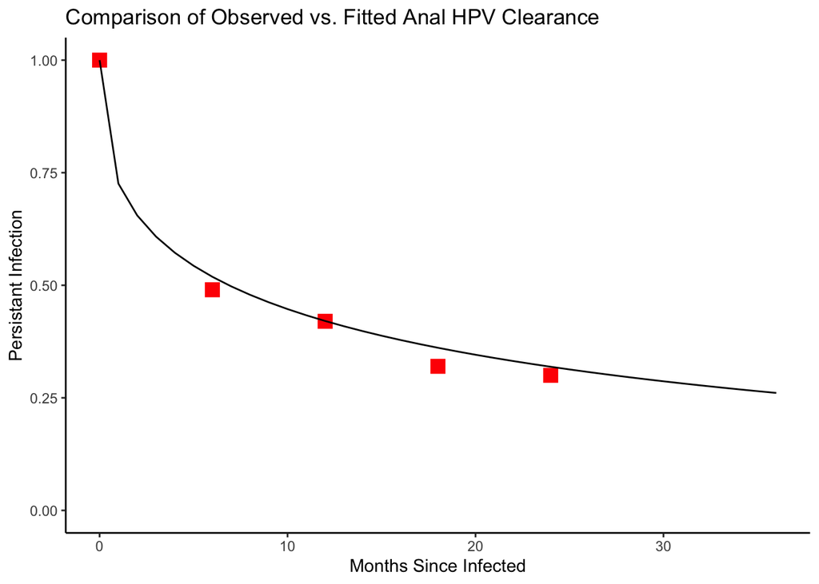

```r
df.lifetable            <- data.frame(read_excel("./_2A_Inputs/mortality.xlsx", sheet="Sheet1"))


v.mortality_rate_m      <- df.lifetable$Male

# rate per person, per week
v.mrm_pp_pw             <- v.mortality_rate_m / 1e5 / 12

# Build out a mortality rate vector

v.age_spans             <-c(1,4,5,5,5,5,5,5,5,5,5,5,5,5,5,5,5,5,5)

v.mort                  <- rep(v.mrm_pp_pw, times = v.age_spans)

df.mort_all             <- (data.frame(c(0:89), v.mort))
colnames(df.mort_all)   <-  c("Age", "Male")



#Create probability of regression of anal HPV- test this again the input data
#Anal Clearance Data from Nyitray 2016- Clinical Infetious Disease
#Penile Clearance Data from Ingles 2015- Papillomavirus Research
#Scale and shape parameters were derived in excel because I'm basic.

df.Nyitray              <- data.frame("months"=c(0,6,12,18,24), "persist"=c(1, 0.49, 0.42, 0.32, 0.3))
df.Ingles               <- data.frame("months"=c(0,12,24,36), "persist"=c(1, 0.45, 0.2, 0.14))

v.time                  <- seq(0,36)
v.a.weibull             <- pweibull(v.time, 0.4, scale = 17.2, log.p = FALSE)
v.g.weibull             <- pweibull(v.time, 0.6, scale = 14.2, log.p = FALSE)

w.for_graph             <- data.frame("time"=c(v.time), "inf_a"=1-v.a.weibull, "inf_p"=1-v.g.weibull)


ggplot() +
  geom_point(aes(x=df.Nyitray$months, y=df.Nyitray$persist), color="red", shape=15, size=4) +
  geom_line(aes(x=w.for_graph$time, y=w.for_graph$inf_a), lstyle="dash") +    theme_classic() +
  ylim(0,1) + ggtitle("Comparison of Observed vs. Fitted Anal HPV Clearance") +
  ylab("Persistant Infection") + xlab("Months Since Infected")
```

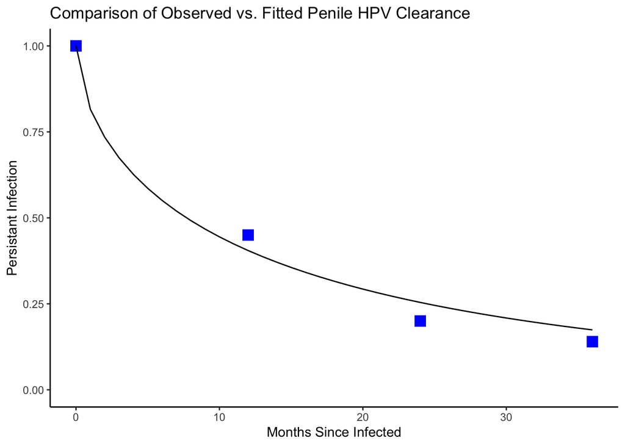

```r
ggplot() +
  geom_point(aes(x=df.Ingles$months, y=df.Ingles$persist), color="blue", shape=15, size=4) +
  geom_line(aes(x=w.for_graph$time, y=w.for_graph$inf_p), lstyle="dash") +    theme_classic() +
  ylim(0,1) + ggtitle("Comparison of Observed vs. Fitted Penile HPV Clearance") +
  ylab("Persistant Infection") + xlab("Months Since Infected")
```

```r
v.rec.month.A             <- (v.a.weibull[2:37] - v.a.weibull[1:36])
v.rec.month.G             <- (v.g.weibull[2:37] - v.g.weibull[1:36])
```

Then we create our target stats. We will define the total number of *edges* (partnerships) at any given point, as well as the number of nodes we expect to be in multiple partnerships concurrently. We will also set restrictions by position- for example, two exclusively receptive men should never form a partnership. Finally, if we don’t set expectations by position we end up with a lot more versatile nodes in relationships- so I set an expectation for this value.

```r
mean_degree             <- as.vector((df.mean_deg_msm[2,1] + (2*df.mean_deg_msm[3,1]))/100)
n.concurrent            <- as.vector(df.mean_deg_msm[3,1]/100)
age_diff                <- 4.6  #!! Add code to pull this from NSFG!!

#Total number of men x mean degree x 0.5 (1 edge per 2 people)
edges                   <- (n*mean_degree*0.5)

#Then stats based on this- first edges total, the concurrent, then all possible combinations that should be impossible
#(ie, two men who only have sex with women can never have a partnership)
# Impossible combinations: FB.FM, FF.FM, FM.FM, FF.MB, FF.MF, MB.MF, MF.MF, FB.MM, FF.MM, FM.MM, MF.MM

targets                 <- c( edges ,          #total edges
                           (n*n.concurrent),   #concurrent nodes
                            edges*age_diff,  #age assortiveness
                              0,              #no receptive only x receptive only partnerships
                              0,              #no insertive only x insertive only partnerships
                              0,              #no sex if not sexually active
                         (edges*pct.pos_v*2)) #Set expected number of versatile nodes- 2*total edges*portion of pop that is Vs.
```

###Model Fit

Now we use the ERGM componants to fit a model. We need the dissolution model (chance that a relationship ends) and the formation model (change that two nodes form a new relationship). Our formation model will match the target stats described above. Our dissolution model will consider only relationship duration and adjust this by the death rate.

```r
# set.seed(041789)

#Dissolution Model
f.coef.diss             <- dissolution_coefs( dissolution = (~offset(edges)),
                                               duration   = c(msm_duration),
                                                d.rate    = mean(df.mort_all$Male))

#Formation model
 f.form                 <- ~edges  +
                           concurrent  +
                           absdiff("age") +
                          nodemix("position", levels2=c(1,3))  +
                          nodefactor("sex.actv", levels=c(1))  +
                          nodefactor("position", levels=c(3)) # +
                         # #degree(4)


#Now make the formation model which is conditional on the dissolution model
fit1                    <- netest(net1,
                                 formation    = f.form,
                                 target.stats = targets,
                                 #edapprox     = FALSE,
                                 coef.diss    = f.coef.diss)
```

```
## Observed statistic(s) mix.position.Insertive.Insertive, mix.position.Receptive.Receptive, and nodefactor.sex.actv.0 are at their smallest attainable values. Their coefficients will be fixed at -Inf.
```

```
## Unable to match target stats. Using MCMLE estimation.
```

[output not shown]

[output not shown]

[output not shown]

[output not shown]

[output not shown]

[output not shown]

[output not shown]

[output not shown]

[output not shown]

[output not shown]

[output not shown]

[output not shown]

[output not shown]

[output not shown]

```
## This model was fit using MCMC.  To examine model diagnostics and
## check for degeneracy, use the mcmc.diagnostics() function.
```

```r
summary(fit1)
```

```
##
## ==========================
## Summary of model fit
## ==========================
##
## Formula:   TARGET_STATS ~ edges + concurrent + absdiff("age") + nodemix("position",
##     levels2 = c(1, 3)) + nodefactor("sex.actv", levels = c(1)) +
##     nodefactor("position", levels = c(3))
## <environment: 0x7f843376ba38>
##
## Iterations:  2 out of 20
##
## Monte Carlo MLE Results:
##                                  Estimate Std. Error MCMC % z value
## edges                            -2.04671    0.23732      0  -8.624
## concurrent                       -2.70391    0.26472      0 -10.214
## absdiff.age                      -0.20765    0.01705      0 -12.180
## mix.position.Insertive.Insertive     -Inf    0.00000      0    -Inf
## mix.position.Receptive.Receptive     -Inf    0.00000      0    -Inf
## nodefactor.sex.actv.0                -Inf    0.00000      0    -Inf
## nodefactor.position.Versatile    -0.53305    0.14010      0  -3.805
##                                  Pr(>|z|)
## edges                             < 1e-04 ***
## concurrent                        < 1e-04 ***
## absdiff.age                       < 1e-04 ***
## mix.position.Insertive.Insertive  < 1e-04 ***
## mix.position.Receptive.Receptive  < 1e-04 ***
## nodefactor.sex.actv.0             < 1e-04 ***
## nodefactor.position.Versatile    0.000142 ***
## ---
## Signif. codes:  0 '***' 0.001 '**' 0.01 '*' 0.05 '.' 0.1 ' ' 1
##
## Log-likelihood was not estimated for this fit.
## To get deviances, AIC, and/or BIC from fit `object$fit` run
##   > object$fit<-logLik(object$fit, add=TRUE)
## to add it to the object or rerun this function with eval.loglik=TRUE.
##
##  Warning: The following terms have infinite coefficient estimates:
##   mix.position.Insertive.Insertive mix.position.Receptive.Receptive nodefactor.sex.actv.0
##
## Dissolution Coefficients
## =======================
## Dissolution Model: ~offset(edges)
## Target Statistics: 71.60938
## Crude Coefficient: 4.257163
## Mortality/Exit Rate: 0.001610156
## Adjusted Coefficient: 4.519072
```

```r
#to test
  #dx.static     <- netdx(fit1, nsims = 1000, dynamic=FALSE)
  #dx.static
```

Simulate our model over 1000 time steps to see if it matches our expectation.

```
##
## Network Diagnostics
## -----------------------
## - Simulating 3 networks
## - Calculating formation statistics
## - Calculating duration statistics
## - Calculating dissolution statistics
##
```

```
##                                     Target   Sim Mean  Pct Diff    Sim SD
## edges                            153.82159 155.383333  1.015292  8.661759
## concurrent                        22.71533  24.473333  7.739282  5.170061
## nodefactor.position.Insertive           NA  81.570667        NA  6.690585
## nodefactor.position.Receptive           NA  54.326333        NA  6.783695
## nodefactor.position.Versatile    172.28019 174.869667  1.503064 10.338003
## absdiff.age                      707.57933 699.289233 -1.171614 76.816989
## degree0                                 NA 231.240667        NA 11.448658
## degree1                                 NA 244.286000        NA 11.376233
## degree2                                 NA  13.145000        NA  3.671394
## degree3                                 NA   6.966667        NA  2.772746
## mix.position.Insertive.Insertive   0.00000         NA        NA        NA
## mix.position.Receptive.Receptive   0.00000         NA        NA        NA
## nodefactor.sex.actv.0              0.00000         NA        NA        NA
```

###Model Diagnostics

Check to make sure our model matches up with all the things we think it should

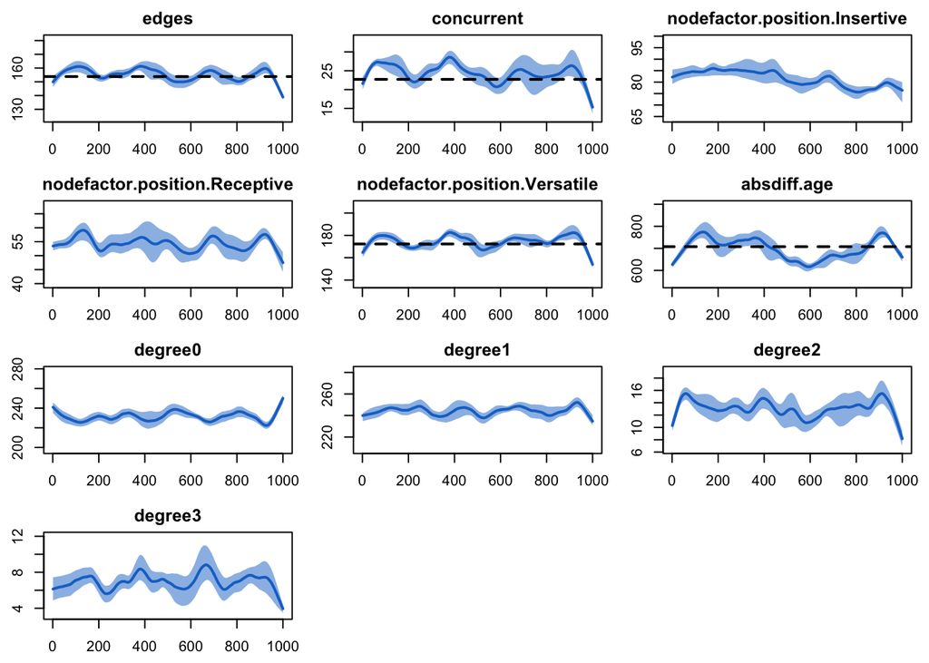

```r
#we can also make fit graphs
plot(dx_sim, type  = "formation" )
```

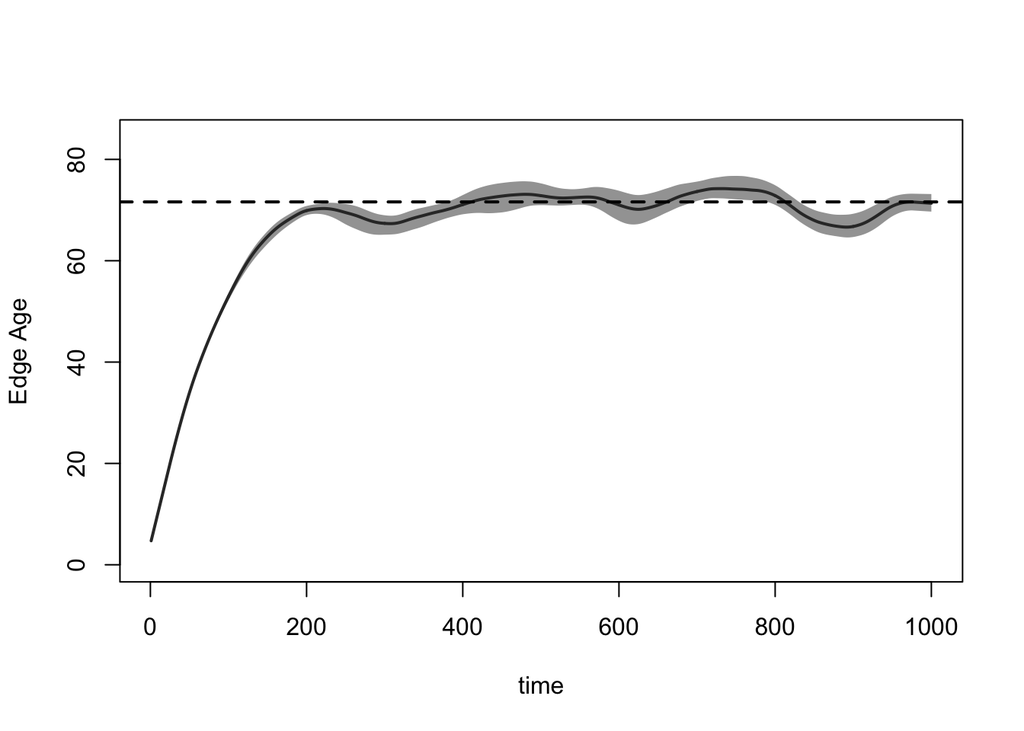

```r
plot(dx_sim, type  = "duration")
```

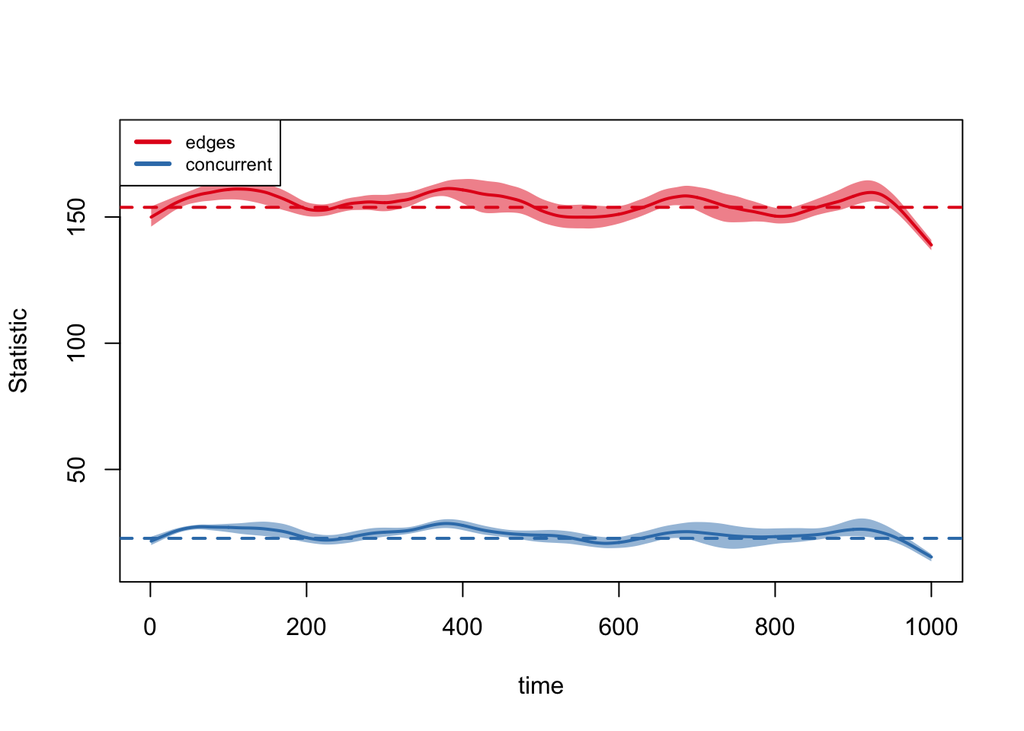

```r
plot(dx_sim, stats = c("edges", "concurrent"))
```

```r
#Check concurrency by group
tel_inf                 <- data.frame(behav= get.vertex.attribute(net1, "behavior"),ID= (get.vertex.attribute(net1, "vertex.names")))
tel_dx                  <- as.data.frame(dx_sim, sim = 1)
tel_dx$ID               <- tel_dx$tail
together1               <- merge(tel_inf, tel_dx, by.y="ID")

tel_dx$ID               <- tel_dx$head
together2               <- merge(tel_inf, tel_dx, by.y="ID")

together                <-rbind(together1,together2)
together$count          <- 1
together                <- together[which(together$terminus.censored==TRUE),]

count_by_ID             <-aggregate(together[11], list(together$ID, together$behav), sum)

MM_conc                 <- length(count_by_ID$count[which(count_by_ID$count>=2 & count_by_ID$Group.2=="MM")])/n.msmo
```

##Running an Infection Model

Now that we have a basic partnerhip model, we can run an infection over it.

We first pull in our model functionts- these are created in *05_Model_Functions.R*

**aging.FUN** Ages individuals by 1 month in each time step

**arrivals.FUN** Introduces new individuals to the population at a birth rate that is a function of the average mortality rate

**departures.FUN** Removes individuals from the population according to the provided *mortality.rates* which are a vector of mortality by age

**infection.FUN** This controls HPV infection through sexual partnerships. It requires the number of sex acts per month *act rate* and the infection probability of anal to penile transmission (*inf.prob.i*) and of penile to anal transmission (*inf.prob.r*). This overrides the baseline infection function.

**recovery.FUN** Allows individuals to clear HPV infections. Modeled separately by site according to *rec.rate.a* and *rec.rate.g*

**epi.FUN** This stores all of the outputs we are interested in collecting

```r
source("./05_Model_Functions.R")

  simtime               <- 1500
  n.sims                <- 1

#  test <- function(vector){
#
#    mean(vector)
#
#    browser()
#  }

#  test(targets)

 # Parameterizing an SIS epidemic
 param                  <- param.net( inf.prob = 0.0001,
                               mortality.rates = (df.mort_all),
                                    birth.rate = (mean(df.mort_all$Male)),
                                    rec.rate.a = v.rec.month.A,
                                    rec.rate.g = v.rec.month.G,
                                    rec.rate   = .00001,
                                    act.rate   = 5.5,
                                    inf.prob.r = 0.33,
                                    inf.prob.i = 0.05)
 order_list             <- c("infection.FUN", "aging.FUN", "departures.FUN", "recovery.FUN", "arrivals.FUN", "epi.FUN")

 # Initial conditions
 init                   <- init.net(i.num = n*0.1)

 start.time             <- Sys.time()
 # Control setting
 control                <- control.net(type = "SIS",
                                      nsims = n.sims,
                                     ncores = 8,
                                     nsteps = simtime,
                               infection.FUN = f.inf_msm,
                                   aging.FUN = age.func,
                                recovery.FUN = f.recovery,
                              departures.FUN = d.func,
                                arrivals.FUN = b.func,
                                     epi.FUN = epi.func,
                              keep.tedgelist = TRUE,
                               keep.tnetwork = TRUE,
                                delete.nodes = FALSE,
                                      depend = TRUE,
                           #    module.order = order_list,
                                     verbose = FALSE)


# Run the network model simulation with netsim
sim_short               <- netsim(fit1, param, init, control)

 stop.time              <- Sys.time()
(total.time             <- stop.time - start.time)
```

```
## Time difference of 14.77005 mins
```

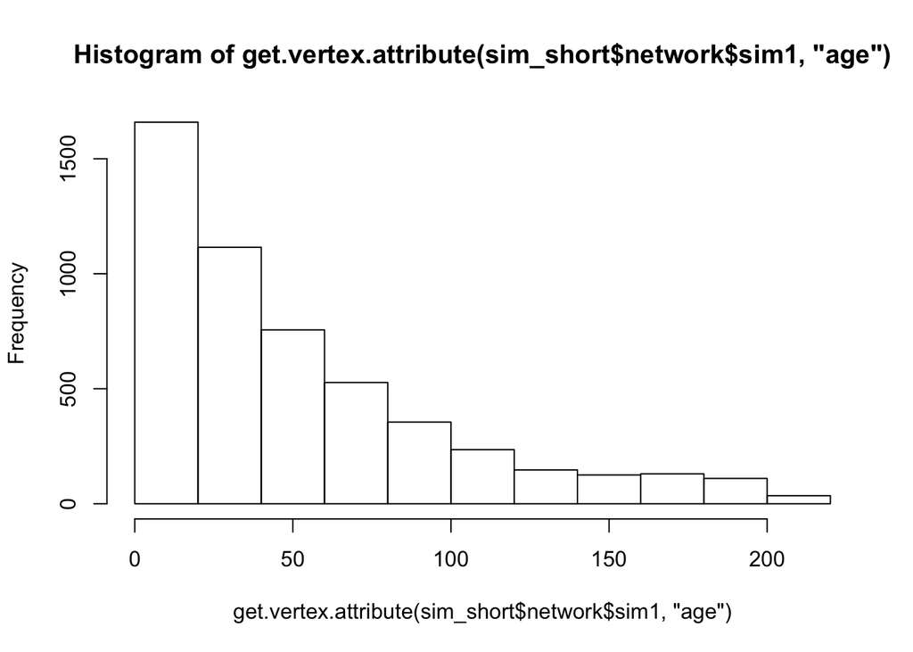

```r
#plot(sim_short)

 #put the data from this simulation
out_sim                 <- as.data.frame(sim_short)
tel_sim                 <- as.data.frame(sim_short$network$sim1)

 #Graph of age at sexual behavior onset
 #ggplot()+ geom_point(aes(x=sex_age, y=age_out, col=sex_out))

#Age distribution of final network
 hist(get.vertex.attribute(sim_short$network$sim1, "age"))
```

```r
     n2                 <- network.size(sim_short$network$sim1)

#beep to tell me you're done
     beep(2)
```

###Infection Plot by Positio

We graph infection over time by position- we should expect exclusively receptive individuals cannot get penile HPV and exclusively insertive individuals cannot get anal HPV. For comparison I have also provided the target prevalance of HPV 16 by site (for overall)

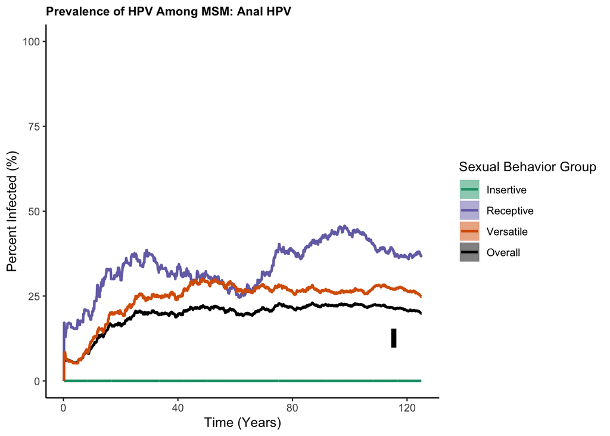

```r
  time                  <- c(seq(1, simtime,1))/12



  f.minmax              <- function(stat) {
  stat_mean             <-apply(stat, 1, mean)*100
  stat_max              <-apply(stat, 1, max)*100
  stat_min              <-apply(stat, 1, min)*100

 stat_out               <- data.frame(mean=stat_mean[2:simtime], max=stat_max[2:simtime], min=stat_min[2:simtime], time=(seq(2, simtime, 1)/12))

  return(stat_out)
  }

  overall               <- f.minmax(sim_short$epi$prv_a.MM)
  overall$group         <- "Overall"

  versatile             <- f.minmax(sim_short$epi$prv_a.v)
  versatile$group       <- "Versatile"

  receptive             <- f.minmax(sim_short$epi$prv_a.r)
  receptive$group       <- "Receptive"

  insertive             <- f.minmax(sim_short$epi$prv_a.i)
  insertive$group       <- "Insertive"


  together_a            <- rbind(overall, versatile, receptive, insertive)



    ggplot() +
         geom_line(aes(y=together_a$mean ,
                       x=together_a$time,
                   color=together_a$group), size=1) +
    geom_ribbon(aes(ymin=together_a$max,
                    ymax=together_a$min,
                       x=together_a$time, fill=together_a$group), alpha=0.5)  +
                        theme_classic() +
                        ylim(0,100) +
                        scale_color_manual(name="Sexual Behavior Group",
                                          breaks=c("Insertive", "Receptive", "Versatile", "Overall"),
                                          values=c("Insertive"="#1b9e77",
                                                   "Receptive"="#7570b3",
                                                   "Versatile"="#d95f02",
                                                   "Overall"="black")) +

                        scale_fill_manual(name="Sexual Behavior Group",
                                          breaks=c("Insertive", "Receptive", "Versatile", "Overall"),
                                          values=c("Insertive"="#1b9e77",
                                                   "Receptive"="#7570b3",
                                                   "Versatile"="#d95f02",
                                                   "Overall"="black")) +
                        theme(panel.background = element_rect(fill = NA),
                        plot.title = element_text(size = 10, face = "bold")) +
                        ggtitle("Prevalence of HPV Among MSM: Anal HPV") +
                        ylab("Percent Infected (%)") +
                        xlab("Time (Years)")  +
                        geom_linerange(aes(x=(simtime/13), ymin=9.8, ymax=15.4), size=2, color="black")
```

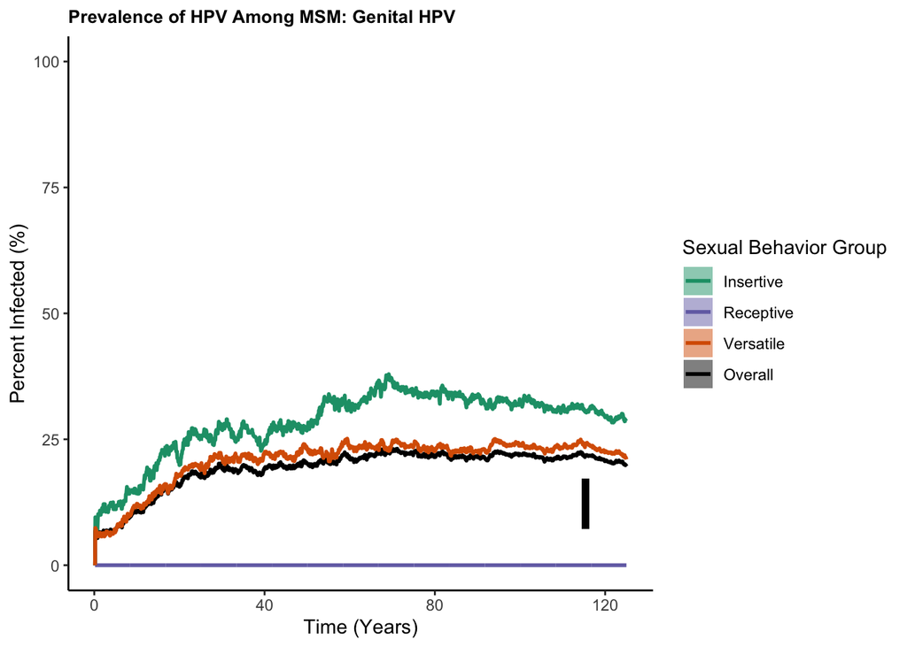

```r
    overall             <- f.minmax(sim_short$epi$prv_g.MM)
  overall$group         <- "Overall"

  versatile             <- f.minmax(sim_short$epi$prv_g.v)
  versatile$group       <- "Versatile"

  receptive             <- f.minmax(sim_short$epi$prv_g.r)
  receptive$group       <- "Receptive"

  insertive             <- f.minmax(sim_short$epi$prv_g.i)
  insertive$group       <- "Insertive"


  together_g            <- rbind(overall, versatile, receptive, insertive)


      ggplot() +
         geom_line(aes(y=together_g$mean ,
                       x=together_g$time,
                   color=together_g$group), size=1) +
    geom_ribbon(aes(ymin=together_g$max,
                    ymax=together_g$min,
                       x=together_g$time,
                    fill=together_g$group), alpha=0.5)  +
                        theme_classic() +
                        ylim(0,100) +
 scale_color_manual(name="Sexual Behavior Group",
                  breaks=c("Insertive", "Receptive", "Versatile", "Overall"),
                  values=c("Insertive"="#1b9e77",
                           "Receptive"="#7570b3",
                           "Versatile"="#d95f02",
                           "Overall"="black")) +

  scale_fill_manual(name="Sexual Behavior Group",
                  breaks=c("Insertive", "Receptive", "Versatile", "Overall"),
                  values=c("Insertive"="#1b9e77",
                          "Receptive"="#7570b3",
                          "Versatile"="#d95f02",
                          "Overall"="black")) +
                        theme(panel.background = element_rect(fill = NA),
                        plot.title = element_text(size = 10, face = "bold")) +
                        ggtitle("Prevalence of HPV Among MSM: Genital HPV") +
                        ylab("Percent Infected (%)") +
                        xlab("Time (Years)") +
                        geom_linerange(aes(x=(simtime/13), ymin=7.2, ymax=17.2), size=2, color="black")
```

### Validation of sexual output

Comparing two pieces of data- first the age of first partnership and second the cumulative number of partnerships over time.

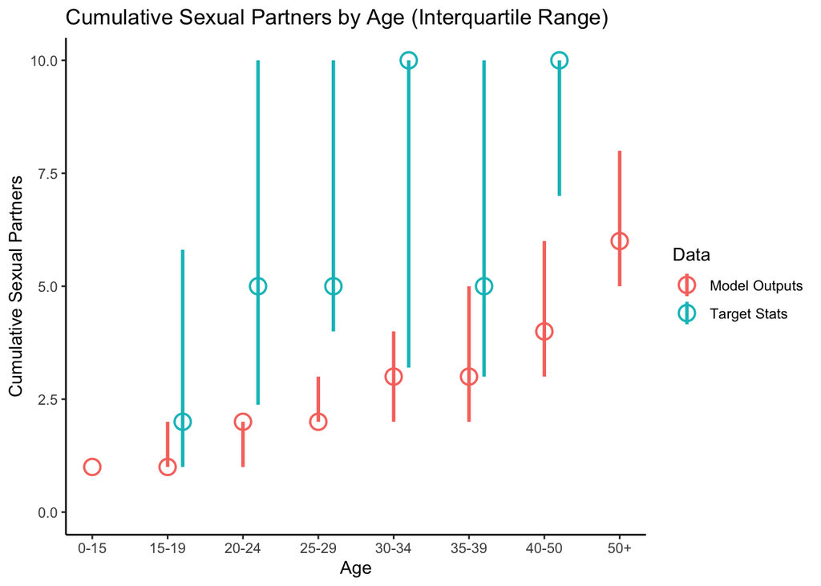

```r
p_total                 <-  (get.vertex.attribute(sim_short$network$sim1, "p_total") )

p_total[
  p_total>10]           <- 10

p_total[
  p_total==0]           <- NA

age                     <-  (get.vertex.attribute(sim_short$network$sim1, "age") )

active2                 <- (get.vertex.attribute(sim_short$network$sim1, "active2") )

agefirst                <-  (get.vertex.attribute(sim_short$network$sim1, "agefirst") )

position                <- (get.vertex.attribute(sim_short$network$sim1, "position") )

combine                 <- data.frame("p_total"=p_total, "age"=age, "active2"=active2, "position"=position, "agefirst"=agefirst)

combine2                <- data.frame("p_total"  =combine$p_total[ which(combine$active2==1)],
                                      "age"      =combine$age[     which(combine$active2==1)],
                                       "position"=combine$position[which(combine$active2==1)],
                                      "agefirst" =combine$agefirst[which(combine$active2==1)])



combine2$age_group      <- NA

combine2$age_group[
  combine2$age<15 ]     <- 1

combine2$age_group[
  combine2$age>=15 &
  combine2$age<20 ]     <- 2

combine2$age_group[
  combine2$age>=20 &
  combine2$age<25 ]     <- 3

combine2$age_group[
  combine2$age>=25 &
  combine2$age<30 ]     <- 4

combine2$age_group[
  combine2$age>=30 &
  combine2$age<35 ]     <- 5

combine2$age_group[
  combine2$age>=35 &
  combine2$age<40 ]     <- 6

combine2$age_group[
  combine2$age>=40 &
  combine2$age<50 ]     <- 7

combine2$age_group[
  combine2$age>=50 ]    <- 8

labels_age              <-c("0-15", "15-19", "20-24", "25-29", "30-34", "35-39", "40-50", "50+")




p.50_p                  <- aggregate(combine2$p_total, list(combine2$age_group), median, na.rm=TRUE)
p.25_p                  <- aggregate(combine2$p_total, list(combine2$age_group), quantile, probs = 0.25, na.rm=TRUE)
p.75_p                  <- aggregate(combine2$p_total, list(combine2$age_group), quantile, probs = 0.75, na.rm=TRUE)
average_p               <- aggregate(combine2$p_total, list(combine2$age_group), mean, na.rm=TRUE)
sd_p                    <- aggregate(combine2$p_total, list(combine2$age_group), sd, na.rm=TRUE)
UCL_p                   <- average_p$x + (sd_p$x)
LCL_p                   <- average_p$x - (sd_p$x)
LCL_p[1]                <- 0

average_model           <- data.frame("age"=p.50_p$Group.1,
                                "p_year.25"=p.25_p$x,
                                "p_year.50"=p.50_p$x,
                                "p_year.75"=p.75_p$x,
                                "average_p"=average_p$x,
                                     "ci_l"=LCL_p,
                                     "ci_u"=UCL_p,
                                     "data"="Model Outputs")

df.msm.byage            <- df.t.byage_median[which(df.t.byage_median$behav=="MSM" & df.t.byage_median$measure=="Total"),]
df.msm.byage_mean       <- df.t.byage_mean[1:6,]

df.msm.byage$age        <- c(2.2,3.2,4.2,5.2,6.2,7.2)
targets                 <- cbind(df.msm.byage[,1] ,df.msm.byage[,3:5], df.msm.byage_mean[2:4])
targets$data            <- "Target Stats"
colnames(targets)       <- c("age", "p_year.25", "p_year.50", "p_year.75", "average_p", "ci_l", "ci_u", "data" )

both                    <- rbind(average_model, targets)


ggplot()+
   geom_pointrange(aes(x=both$age,
                       y=both$p_year.50,
                    ymin=both$p_year.25,
                    ymax=both$p_year.75, color=both$data) , shape=1, size=1) +
 #    geom_jitter( aes(y=combine2$p_total,
#                      x=combine2$age_group), alpha=.04, color="red") +
                        theme_classic() +
                        ylim(0,10) +
                        ggtitle("Cumulative Sexual Partners by Age (Interquartile Range)") +
                        ylab("Cumulative Sexual Partners") +
                        xlab("Age") +
                        scale_x_continuous(breaks=c(1,2,3,4,5,6,7,8), labels=labels_age) +
                        labs(color="Data")
```

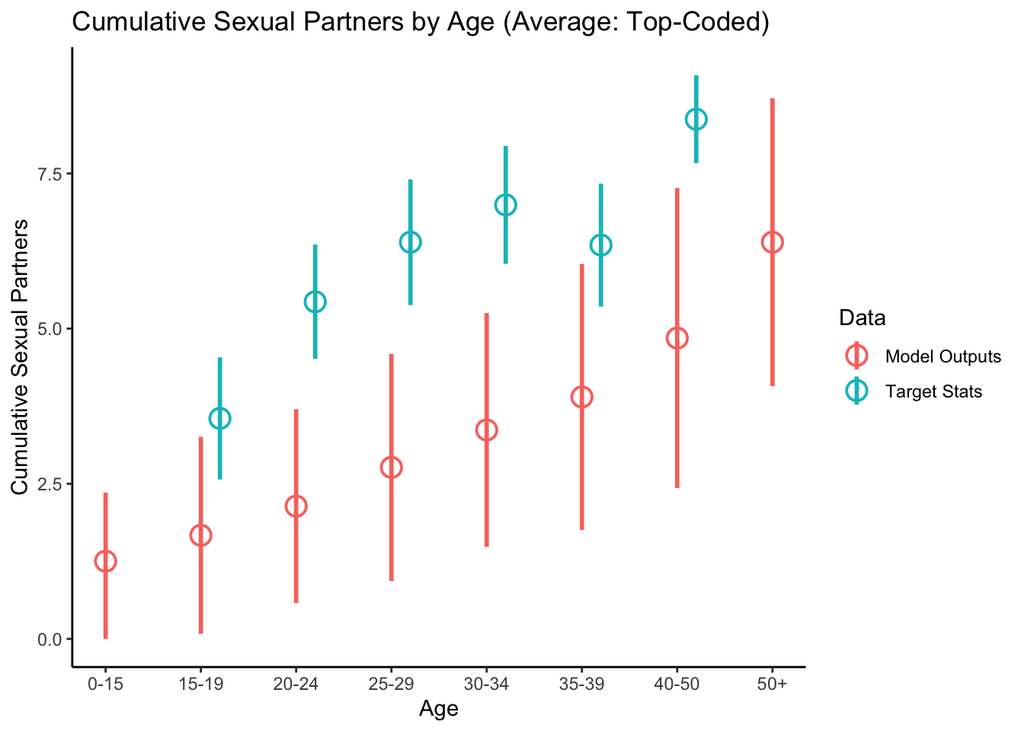

```r
ggplot()+
   geom_pointrange(aes(x=both$age,
                       y=both$average_p,
                    ymin=both$ci_l,
                    ymax=both$ci_u, color=both$data) , shape=1, size=1) +
 #   geom_jitter(  aes(y=combine2$p_total,
  #                    x=combine2$age_group), alpha=.04, color="red") +
                        theme_classic() +
                        ggtitle("Cumulative Sexual Partners by Age (Average: Top-Coded)") +
                        ylab("Cumulative Sexual Partners") +
                        xlab("Age") +
                        scale_x_continuous(breaks=c(1,2,3,4,5,6,7,8), labels=labels_age) +
                        labs(color="Data")
```

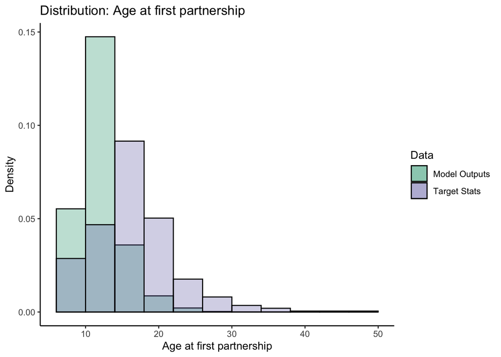

```r
  age_compare            <- data.frame("age"=c(v.t.agefirst_msm, combine2$agefirst),
                                       "data"=c(rep("Target Stats", length(v.t.agefirst_msm)),
                                                rep("Model Outputs", length(combine2$agefirst))))


  ggplot()+
    geom_histogram(aes(age_compare$age[age_compare$data=="Model Outputs"],
                       fill=age_compare$data[age_compare$data=="Model Outputs"],
                      alpha=age_compare$data[age_compare$data=="Model Outputs"], y=..density..), color="black", binwidth = 4) +
    geom_histogram(aes(age_compare$age[age_compare$data=="Target Stats"],
                      fill=age_compare$data[age_compare$data=="Target Stats"],
                     alpha=age_compare$data[age_compare$data=="Target Stats"], y=..density..), color="black", binwidth = 4) +
    scale_fill_manual(name="Data",
                    values=c("Model Outputs"="#1b9e77", "Target Stats"="#7570b3"))+
   scale_alpha_manual(name="Data",
                   values=c("Model Outputs"=0.3, "Target Stats"=0.3))+
                          theme_classic() +
                          ggtitle("Distribution: Age at first partnership") +
                          ylab("Density") +
                          xlab("Age at first partnership")
```

```r
# # Parameterizing an SIS epidemic
# param             <- param.net( inf.prob = 0.0001,
#                          mortality.rates = (mort_all),
#                               birth.rate = (mean(mort_all$Male)),
#                               rec.rate.a = rec.month.A,
#                               rec.rate.g = rec.month.G,
#                               rec.rate   = .00001,
#                               act.rate   = 5.5,
#                               inf.prob.r = 0.33,
#                               inf.prob.i = 0.05)

# order_list      <- c("infection.FUN", "aging.FUN", "departures.FUN", "recovery.FUN", "arrivals.FUN", "epi.FUN")
#
# # Initial conditions
# init              <- init.net(i.num = 0)
#
# start.time        <- Sys.time()
# # Control settings
# control           <- control.net(type = "SIS",
#                                 nsims = n.sims,
#                                ncores = 8,
#                                nsteps = simtime,
#                          infection.FUN = f.inf_msm,
#                              aging.FUN = age.func,
#                           recovery.FUN = f.recovery,
#                         departures.FUN = d.func,
#                           arrivals.FUN = b.func,
#                                epi.FUN = epi.func,
#                         keep.tedgelist = TRUE,
#                          keep.tnetwork = TRUE,
#                           delete.nodes = FALSE,
#                                 depend = TRUE,
#                      #    module.order = order_list,
#                                verbose = TRUE)
#
#
## Run the network model simulation with netsim
#sim_short          <- netsim(fit1, param, init, control)
#
```